Data and Code Management / Autumn 2026

# Code literacy I

## Read, change and check data code

### Samuel Orso · HEC Lausanne · Data and Code Management

### Thursday, 8 October 2026

# Last week: a project someone else can use

This week: can you explain what its code does?

## Before you run

Predict the values, rows or columns that will change.

## After you run

Compare the result with your prediction and the data.

Predict → run → compare

Read, explain, make a small change, and sanity-check. Python live; R tabs are alternatives.

# Five players, one table

| Player · row label | date_of_birth | grand_slam_win |
| --- | --- | --- |
| Novak Djokovic | 1987-05-22 | 16 |
| Rafael Nadal | 1986-06-03 | 19 |
| Roger Federer | 1981-08-08 | 20 |
| Daniil Medvedev | 1996-02-11 | 0 |
| Dominic Thiem | 1993-09-03 | 0 |

One row = one player. A column = one variable.

Supplied historical teaching fixture · 30 September 2019.  
Names are row labels in both language versions; zeros are observed title counts.

# Assignment gives a value a name

<form class="lang-tabs" role="group" aria-label="Choose example language">
<input class="choose-python" type="radio" name="language-1" id="python-1" checked><label for="python-1">Python · live</label>
<input class="choose-r" type="radio" name="language-1" id="r-1"><label for="r-1">R alternative</label>
<pre><code data-lang="python">grand&#95;slam&#95;win = &#91;16, 19, 20, 0, 0&#93;
grand&#95;slam&#95;win
len(grand&#95;slam&#95;win)</code></pre>
<pre><code data-lang="r">grand&#95;slam&#95;win &lt;- c(16, 19, 20, 0, 0)
grand&#95;slam&#95;win
length(grand&#95;slam&#95;win)</code></pre>
</form><p class="question">What does the name refer to? How many values are there?</p><p class="note">These are the table’s five title counts, in player order. A name refers to data; assignment is not an equality test.</p>

# Choose the object that fits the data

## A sequence of values

One variable: the five title counts.

A Python list or R vector keeps values in order.

## A table of observations

One row per player; birth date and titles stay together.

Different columns can have different types.

[figure not shown]

Python · live R alternative

```
sum(grand_slam_win)
import statistics as st
st.mean(grand_slam_win)
```

```
sum(grand_slam_win)
mean(grand_slam_win)
```

# Inspect the object; predict the conversion

<form class="lang-tabs" role="group" aria-label="Choose example language">
<input class="choose-python" type="radio" name="language-3" id="python-3" checked><label for="python-3">Python · live</label>
<input class="choose-r" type="radio" name="language-3" id="r-3"><label for="r-3">R alternative</label>
<pre><code data-lang="python">type(12.5), type(2), type(True), type(&quot;hi&quot;)
val = &#91;True, 2, &quot;3&quot;&#93;
val
import numpy as np
np.array(val)</code></pre>
<pre><code data-lang="r">typeof(12.5); typeof(2L); typeof(TRUE); typeof(&quot;hi&quot;)
val &lt;- c(TRUE, 2, &quot;3&quot;)
val
typeof(val)</code></pre>
</form><p class="question">Which values stay numeric? Predict before running.</p><p class="note">Our table has numeric counts and dates stored as text. What happens when types mix?</p>

# A number written as text is still text

| Container | Result for the mixed example |
| --- | --- |
| Python list | True, 2, "3" — mixed types |
| NumPy array | "True", "2", "3" — strings |
| R atomic vector | "TRUE", "2", "3" — character |

Inspect types before interpreting an operation.

The values can look numeric without being numbers. Conversion is a data decision, not cosmetic formatting.

# Inspect before extracting

<form class="lang-tabs" role="group" aria-label="Choose example language">
<input class="choose-python" type="radio" name="language-4" id="python-4" checked><label for="python-4">Python · live</label>
<input class="choose-r" type="radio" name="language-4" id="r-4"><label for="r-4">R alternative</label>
<pre><code data-lang="python"># Start from the supplied tennis.py
print(tennis)
tennis.info()
tennis.shape
list(tennis.columns)</code></pre>
<pre><code data-lang="r"># Start from the supplied tennis.R
tennis
str(tennis)
dim(tennis)
names(tennis)</code></pre>
</form><p class="question">Five rows, two columns. Which column still contains text?</p><p class="note">Open the supplied starter in VS Code. <a href="practice/student-guide.html#start">Start instructions</a> include Python and R.</p>

# Position is not the same as a label

<form class="lang-tabs" role="group" aria-label="Choose example language">
<input class="choose-python" type="radio" name="language-5" id="python-5" checked><label for="python-5">Python · live</label>
<input class="choose-r" type="radio" name="language-5" id="r-5"><label for="r-5">R alternative</label>
<pre><code data-lang="python">tennis.iloc&#91;1&#93;                 # second row, by position
tennis.loc&#91;&quot;Rafael Nadal&quot;&#93;     # row with this label</code></pre>
<pre><code data-lang="r">tennis&#91;2, &#93;                    # second row, by position
tennis&#91;&quot;Rafael Nadal&quot;, &#93;       # row with this name</code></pre>
</form>R positions start at 1; Python positions start at 0.<p class="note">pandas: <code>.iloc</code> selects by position; <code>.loc</code> selects by label.Both select Nadal here. After sorting, the second row may be someone else.</p>

# Select columns; keep the rows together

<form class="lang-tabs" role="group" aria-label="Choose example language">
<input class="choose-python" type="radio" name="language-6" id="python-6" checked><label for="python-6">Python · live</label>
<input class="choose-r" type="radio" name="language-6" id="r-6"><label for="r-6">R alternative</label>
<pre><code data-lang="python">wins = tennis&#91;&quot;grand&#95;slam&#95;win&quot;&#93;
cols = tennis&#91;&#91;&quot;grand&#95;slam&#95;win&quot;, &quot;date&#95;of&#95;birth&quot;&#93;&#93;
print(cols)</code></pre>
<pre><code data-lang="r">wins &lt;- tennis&#91;&#91;&quot;grand&#95;slam&#95;win&quot;&#93;&#93;
cols &lt;- tennis&#91;c(&quot;grand&#95;slam&#95;win&quot;, &quot;date&#95;of&#95;birth&quot;)&#93;
cols</code></pre>
</form><p class="question">Did selecting columns remove any players?</p>A single column is a sequence. A table keeps columns together.<p class="note">Check: the same five player labels, with wins still matched to their birth dates.</p>

# A Boolean mask answers one question per row

<form class="lang-tabs" role="group" aria-label="Choose example language">
<input class="choose-python" type="radio" name="language-7" id="python-7" checked><label for="python-7">Python · live</label>
<input class="choose-r" type="radio" name="language-7" id="r-7"><label for="r-7">R alternative</label>
<pre><code data-lang="python">mask = tennis&#91;&quot;grand&#95;slam&#95;win&quot;&#93; &gt; 0
positive = tennis.loc&#91;mask&#93;
print(mask)
print(positive)</code></pre>
<pre><code data-lang="r">mask &lt;- tennis$grand&#95;slam&#95;win &gt; 0
positive &lt;- tennis&#91;mask, &#93;
mask
positive</code></pre>
</form>True, True, True, False, False → three retained players.<p class="note">Djokovic, Nadal, Federer. Zero is a real value; this filter answers “who has titles?”</p>

# Practice · Predict, run, compare

5 minutes · pairs · choose one language

1 min

Use the existing vector `3, 6, 9, 12`. Predict its second value, last value and descending order.

2 min

Select the second and last values. Sort the sequence in descending order.

2 min

Run, compare and explain what each selection means. Show the result to your partner.

Starter values and hints. No comprehensions, custom functions or double implementation.

# Check the values, then explain the syntax

<form class="lang-tabs" role="group" aria-label="Choose example language">
<input class="choose-python" type="radio" name="language-8" id="python-8" checked><label for="python-8">Python · live</label>
<input class="choose-r" type="radio" name="language-8" id="r-8"><label for="r-8">R alternative</label>
<pre><code data-lang="python">x = &#91;3, 6, 9, 12&#93;
x&#91;1&#93;                         # second value
x&#91;-1&#93;                        # last value
sorted(x, reverse=True)</code></pre>
<pre><code data-lang="r">x &lt;- c(3, 6, 9, 12)
x&#91;2&#93;                         # second value
tail(x, 1)                   # last value
sort(x, decreasing = TRUE)</code></pre>
</form>Second: 6. Last: 12. Descending: 12, 9, 6, 3.<p class="note">Check what was selected and whether sorting changed the original sequence. Next: change a table safely.</p>

# A supplied transformation: birth date → age

<form class="lang-tabs" role="group" aria-label="Choose example language">
<input class="choose-python" type="radio" name="language-9" id="python-9" checked><label for="python-9">Python · live</label>
<input class="choose-r" type="radio" name="language-9" id="r-9"><label for="r-9">R alternative</label>
<pre><code data-lang="python">work = tennis.copy()
work&#91;&quot;date&#95;of&#95;birth&quot;&#93; = pd.to&#95;datetime(work&#91;&quot;date&#95;of&#95;birth&quot;&#93;)
ref&#95;date = pd.Timestamp(&quot;2019-09-30&quot;)
work&#91;&quot;age&#95;years&quot;&#93; = (
    (ref&#95;date - work&#91;&quot;date&#95;of&#95;birth&quot;&#93;).dt.days / 365.2425
)
work.shape</code></pre>
<pre><code data-lang="r">work &lt;- tennis
work$date&#95;of&#95;birth &lt;- as.Date(work$date&#95;of&#95;birth)
ref&#95;date &lt;- as.Date(&quot;2019-09-30&quot;)
work$age&#95;years &lt;- as.numeric(
    difftime(ref&#95;date, work$date&#95;of&#95;birth, units = &quot;days&quot;)
) / 365.2425
dim(work)</code></pre>
</form><p class="question">One new column. Why must the row count stay at five?</p><p class="note">Approximate age in years at 30 September 2019. Work on a copy; keep the original table.</p>

# Practice · Change the question, check the table

10 minutes · one language · supplied tennis starter

3 min

Run the supplied age transformation. Keep players with **more than zero** titles; sort whole rows by age, oldest first.

4 min

Change the filter to **at least 19** titles. Predict who stays before running. Display title count and age.

3 min

Check names, row counts and name–value associations. Explain your one-line change to a partner.

Adding a column preserves rows. Filtering changes which rows survive.

Runnable starting code and hints. Plotting is optional after the core task.

# Check the association, not just the row count

<form class="lang-tabs" role="group" aria-label="Choose example language">
<input class="choose-python" type="radio" name="language-10" id="python-10" checked><label for="python-10">Python · live</label>
<input class="choose-r" type="radio" name="language-10" id="r-10"><label for="r-10">R alternative</label>
<pre><code data-lang="python">selected = work.loc&#91;work&#91;&quot;grand&#95;slam&#95;win&quot;&#93; &gt;= 19&#93;
selected = selected.sort&#95;values(&quot;age&#95;years&quot;, ascending=False)
print(selected&#91;&#91;&quot;grand&#95;slam&#95;win&quot;, &quot;age&#95;years&quot;&#93;&#93;)</code></pre>
<pre><code data-lang="r">selected &lt;- work&#91;work$grand&#95;slam&#95;win &gt;= 19, &#93;
selected &lt;- selected&#91;order(-selected$age&#95;years), &#93;
selected&#91;c(&quot;grand&#95;slam&#95;win&quot;, &quot;age&#95;years&quot;)&#93;</code></pre>
</form><table><thead><tr><th>Check</th><th>Expected</th></tr></thead><tbody><tr><td>Original → age column</td><td>5 × 2 → 5 × 3; original unchanged</td></tr><tr><td>Positive titles → at least 19</td><td>3 players → 2 players</td></tr><tr><td>Final order and titles</td><td>Federer: 20; Nadal: 19</td></tr></tbody></table><p class="note">Sorting a whole table moves each player’s values together. The original title total remains 55.</p>

# Five rows, plausible values — wrong players

Deliberately wrong: sort only the title values, then assign them back.

Python · live R alternative

```
broken = work.copy()
broken["grand_slam_win"] = sorted(work["grand_slam_win"])
```

```
broken <- work
broken$grand_slam_win <- sort(work$grand_slam_win)
```

| Player | Original titles | After this assignment |
| --- | --- | --- |
| Novak Djokovic | 16 | 0 |
| Roger Federer | 20 | 16 |

Still five rows and 55 titles. What has gone wrong?

The values lost their player associations. Sort whole rows together.

# Understanding missing-value behavior

## Different meanings

**0 titles**: an observed count in our tennis table.

**NA / NaN**: a title count is unknown or unrecorded.

**Empty text** is not automatically missing.

## Two different decisions

1. Detect which values are missing.

2. Decide what the analysis should do about them.

Detection does not justify deletion or filling.

Python · live R alternative

```
sample = np.array([2, np.nan, 4])
np.isnan(sample)
```

```
sample <- c(2, NA, 4)
is.na(sample)
```

# Which values does the mean include?

<form class="lang-tabs" role="group" aria-label="Choose example language">
<input class="choose-python" type="radio" name="language-12" id="python-12" checked><label for="python-12">Python · live</label>
<input class="choose-r" type="radio" name="language-12" id="r-12"><label for="r-12">R alternative</label>
<pre><code data-lang="python">np.mean(sample)
np.nanmean(sample)
pd.Series(sample).mean()
pd.Series(sample).mean(skipna=False)</code></pre>
<pre><code data-lang="r">mean(sample)
mean(sample, na.rm = TRUE)</code></pre>
</form><table><thead><tr><th>For 2, missing, 4</th><th>Result</th></tr></thead><tbody><tr><td>R mean / NumPy mean</td><td>Missing</td></tr><tr><td>R na.rm = TRUE / NumPy nanmean</td><td>3 = (2 + 4) / 2</td></tr><tr><td>pandas Series.mean() default</td><td>3; skips missing values here</td></tr></tbody></table><p class="note">State the denominator. A missing-skipping mean is not an automatic missing-data policy.</p>

# Better performance ≠ better learning?

If ChatGPT helps students complete programming exercises, do you expect them to understand the code better?

Predict in pairs · then reveal

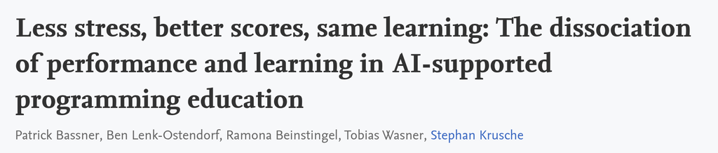

TUM · publication page ↗

**What did Bassner et al. (2026) find?**

## Better task performance

Higher exercise scores.  
Less reported frustration.

## Learning did not rise with it

No detected advantage in knowledge gains or code comprehension.

One 90-minute introductory-programming exercise: ChatGPT, a scaffolded AI tutor, or no AI.

Working code ≠ understood code

[Bassner et al. (2026) · Computers and Education: Artificial Intelligence, 10, 100537](https://doi.org/10.1016/j.caeai.2025.100537)

# AI activity · Predict before asking

Minutes 0–3 · no running · no AI

Python · live R alternative

```
import numpy as np
x = np.arange(1, 11, dtype=float)
x[x % 2 == 1] = np.nan
x
```

```
x <- 1:10
x[x %% 2 == 1] <- NA_integer_
x
```

Predict the values, length, missing count and observed count.

Does this remove elements or replace their values? `%` / `%%` is remainder.  
Artificial mechanics example: replacing odd values is not a real-data cleaning rule.

# Ask for an explanation; compare the claims

Minutes 3–5 · keep the original code

Where does the explanation agree or disagree with your prediction?

Name your language and paste the existing snippet. Do not ask for a rewrite.  
No AI access? Compare with a partner’s explanation, then perform the same checks.

**A second AI checks the code. Have I independently verified it?**  
Li et al. (2026): students reported delegating checks to AI. [Study ↗](https://doi.org/10.3390/jintelligence14100232)

# Run the original code; verify independently

Minutes 5–9 · compare against your written prediction

Python · live R alternative

```
len(x), np.isnan(x).sum(), (~np.isnan(x)).sum()
np.nansum(x)
np.mean(x), np.nanmean(x)
pd.Series(x).mean()
np.nan_to_num(x, nan=0).mean()
```

```
length(x); sum(is.na(x)); sum(!is.na(x))
sum(x, na.rm = TRUE)
mean(x); mean(x, na.rm = TRUE)
zero_filled <- x
zero_filled[is.na(zero_filled)] <- 0
mean(zero_filled)
```

Check the displayed values and do the retained-value sum by hand.

Run the original snippet first. Then check counts and means.  
Zero filling is a comparison of consequences, not a recommended repair.

# Correct arithmetic is not a cleaning justification

Minutes 9–12 · debrief

| Check | Expected evidence |
| --- | --- |
| Length / missing / observed | 10 / 5 / 5 |
| Retained values and sum | 2, 4, 6, 8, 10 → 30 |
| Observed-value mean | 6 = 30 / 5 |
| Mean after zero replacement | 3 = 30 / 10 |

AI can explain code; the analyst remains responsible for  
understanding the operation and validating the output.

R / NumPy ordinary mean: missing. pandas mean here: 6.  
Neither answer establishes that dropping or replacing values is substantively justified.

# A change you can explain and check

Could another analyst trust your explanation?

01

What are the input and the operation?

02

What should change — and what must NOT change?

03

What evidence tells me the result is correct?

Keep your tennis edit, prediction and checks.  
Next week: control flow, functions and debugging — Code Literacy II, 15 October.